# Keras Tutorial: Text Classification

**Source: Keras Package vignette**

We’ll use the [IMDB dataset](https://keras.rstudio.com/reference/dataset_imdb.html) that contains the text of 50,000 movie reviews from the [Internet Movie Database](https://www.imdb.com/). These are split into 25,000 reviews for training and 25,000 reviews for testing. The training and testing sets are balanced, meaning they contain an equal number of positive and negative reviews.

The goal is to predict the kind of review: positive/negative. So this is a binary classification task.

```r
library(keras)
library(dplyr)
```

```r
library(ggplot2)
library(purrr)
```

# Download the IMDB dataset

The IMDB dataset comes packaged with Keras. It has already been preprocessed such that the reviews (sequences of words) have been converted to sequences of integers, where each integer represents a specific word in a dictionary.

The following code downloads the IMDB dataset to your machine (or uses a cached copy if you’ve already downloaded it):

```r
imdb <- dataset_imdb(num_words = 10000)

c(train_data, train_labels) %<-% imdb$train
c(test_data, test_labels) %<-% imdb$test
```

The argument `num_words = 10000` keeps the top 10,000 most frequently occurring words in the training data. The rare words are discarded to keep the size of the data manageable.

Conveniently, the dataset comes with an index mapping words to integers, which has to be downloaded separately:

```r
word_index <- dataset_imdb_word_index()
glimpse(word_index)
```

```
## List of 88584
##  $ fawn                                               : int 34701
##  $ tsukino                                            : int 52006
##  $ nunnery                                            : int 52007
##  $ sonja                                              : int 16816
##  $ vani                                               : int 63951
##  $ woods                                              : int 1408
##  $ spiders                                            : int 16115
##  $ hanging                                            : int 2345
##  $ woody                                              : int 2289
##  $ trawling                                           : int 52008
##  $ hold's                                             : int 52009
##  $ comically                                          : int 11307
##  $ localized                                          : int 40830
##  $ disobeying                                         : int 30568
```

[output cut: 86 more lines]

# Explore the data

The dataset comes preprocessed: each example is an array of integers representing the words of the movie review. Each label is an integer value of either 0 or 1, where 0 is a negative review, and 1 is a positive review.

```r
paste0("Training entries: ", length(train_data), ", labels: ", length(train_labels))
```

```
## [1] "Training entries: 25000, labels: 25000"
```

The texts of the reviews have been converted to integers, where each integer represents a specific word in a dictionary. Here’s what the first review looks like:

```r
train_data[[1]]
```

```
##   [1]    1   14   22   16   43  530  973 1622 1385   65  458 4468   66 3941    4
##  [16]  173   36  256    5   25  100   43  838  112   50  670    2    9   35  480
##  [31]  284    5  150    4  172  112  167    2  336  385   39    4  172 4536 1111
##  [46]   17  546   38   13  447    4  192   50   16    6  147 2025   19   14   22
##  [61]    4 1920 4613  469    4   22   71   87   12   16   43  530   38   76   15
##  [76]   13 1247    4   22   17  515   17   12   16  626   18    2    5   62  386
##  [91]   12    8  316    8  106    5    4 2223 5244   16  480   66 3785   33    4
## [106]  130   12   16   38  619    5   25  124   51   36  135   48   25 1415   33
## [121]    6   22   12  215   28   77   52    5   14  407   16   82    2    8    4
## [136]  107  117 5952   15  256    4    2    7 3766    5  723   36   71   43  530
## [151]  476   26  400  317   46    7    4    2 1029   13  104   88    4  381   15
## [166]  297   98   32 2071   56   26  141    6  194 7486   18    4  226   22   21
## [181]  134  476   26  480    5  144   30 5535   18   51   36   28  224   92   25
## [196]  104    4  226   65   16   38 1334   88   12   16  283    5   16 4472  113
## [211]  103   32   15   16 5345   19  178   32
```

Movie reviews may be different lengths. The below code shows the number of words in the first and second reviews. Since inputs to a neural network must be the same length, we’ll need to resolve this later.

```r
length(train_data[[1]])
```

```
## [1] 218
```

```r
length(train_data[[2]])
```

```
## [1] 189
```

#### Convert the integers back to words

It may be useful to know how to convert integers back to text. We already have the `word_index` we downloaded above — a list with words as keys and integers as values. If we create a data frame from it, we can conveniently use it in both directions.

```r
word_index_df <- data.frame(
  word = names(word_index),
  idx = unlist(word_index, use.names = FALSE),
  stringsAsFactors = FALSE
)

# The first indices are reserved
word_index_df <- word_index_df %>% mutate(idx = idx + 3)
word_index_df <- word_index_df %>%
  add_row(word = "<PAD>", idx = 0)%>%
  add_row(word = "<START>", idx = 1)%>%
  add_row(word = "<UNK>", idx = 2)%>%
  add_row(word = "<UNUSED>", idx = 3)

word_index_df <- word_index_df %>% arrange(idx)

decode_review <- function(text){
  paste(map(text, function(number) word_index_df %>%
              filter(idx == number) %>%
              select(word) %>%
              pull()),
        collapse = " ")
}
```

Now we can use the decode_review function to display the text for the first review:

```r
decode_review(train_data[[1]])
```

```
## [1] "<START> this film was just brilliant casting location scenery story direction everyone's really suited the part they played and you could just imagine being there robert <UNK> is an amazing actor and now the same being director <UNK> father came from the same scottish island as myself so i l…
```

# Prepare the data

The reviews — the arrays of integers — must be converted to tensors before fed into the neural network. This conversion can be done a couple of ways:

- One-hot-encode the arrays to convert them into vectors of 0s and 1s. For example, the sequence [3, 5] would become a 10,000-dimensional vector that is all zeros except for indices 3 and 5, which are ones. Then, make this the first layer in our network — a `dense` layer — that can handle floating point vector data. This approach is memory intensive, though, requiring a `num_words * num_reviews` size matrix.
- Alternatively, we can pad the arrays so they all have the same length, then create an integer tensor of shape `num_examples * max_length`. We can use an embedding layer capable of handling this shape as the first layer in our network.

In this tutorial, we will use the second approach.

Since the movie reviews must be the same length, we will use the [pad_sequences](https://keras.rstudio.com/reference/pad_sequences.html) function to standardize the lengths:

```r
train_data <- pad_sequences(
  train_data,
  value = word_index_df %>% filter(word == "<PAD>") %>% select(idx) %>% pull(),
  padding = "post",
  maxlen = 256
)

test_data <- pad_sequences(
  test_data,
  value = word_index_df %>% filter(word == "<PAD>") %>% select(idx) %>% pull(),
  padding = "post",
  maxlen = 256
)
```

Let’s look at the length of the examples now:

```r
length(train_data[1, ])
```

```
## [1] 256
```

```r
length(train_data[2, ])
```

```
## [1] 256
```

And inspect the (now padded) first review:

```r
train_data[1, ]
```

```
##   [1]    1   14   22   16   43  530  973 1622 1385   65  458 4468   66 3941    4
##  [16]  173   36  256    5   25  100   43  838  112   50  670    2    9   35  480
##  [31]  284    5  150    4  172  112  167    2  336  385   39    4  172 4536 1111
##  [46]   17  546   38   13  447    4  192   50   16    6  147 2025   19   14   22
##  [61]    4 1920 4613  469    4   22   71   87   12   16   43  530   38   76   15
##  [76]   13 1247    4   22   17  515   17   12   16  626   18    2    5   62  386
##  [91]   12    8  316    8  106    5    4 2223 5244   16  480   66 3785   33    4
## [106]  130   12   16   38  619    5   25  124   51   36  135   48   25 1415   33
## [121]    6   22   12  215   28   77   52    5   14  407   16   82    2    8    4
## [136]  107  117 5952   15  256    4    2    7 3766    5  723   36   71   43  530
## [151]  476   26  400  317   46    7    4    2 1029   13  104   88    4  381   15
## [166]  297   98   32 2071   56   26  141    6  194 7486   18    4  226   22   21
## [181]  134  476   26  480    5  144   30 5535   18   51   36   28  224   92   25
## [196]  104    4  226   65   16   38 1334   88   12   16  283    5   16 4472  113
## [211]  103   32   15   16 5345   19  178   32    0    0    0    0    0    0    0
## [226]    0    0    0    0    0    0    0    0    0    0    0    0    0    0    0
## [241]    0    0    0    0    0    0    0    0    0    0    0    0    0    0    0
## [256]    0
```

# Build the model

The neural network is created by stacking layers — this requires two main architectural decisions:

- How many layers to use in the model?
- How many hidden units to use for each layer?

In this example, the input data consists of an array of word-indices. The labels to predict are either 0 or 1. Let’s build a model for this problem:

```r
# input shape is the vocabulary count used for the movie reviews (10,000 words)
vocab_size <- 10000

model <- keras_model_sequential()
model %>%
  layer_embedding(input_dim = vocab_size, output_dim = 16) %>%
  layer_global_average_pooling_1d() %>%
  layer_dense(units = 16, activation = "relu") %>%
  layer_dense(units = 1, activation = "sigmoid")

model %>% summary()
```

```
## Model: "sequential"
## ________________________________________________________________________________
## Layer (type)                        Output Shape                    Param #
## ================================================================================
## embedding (Embedding)               (None, None, 16)                160000
## ________________________________________________________________________________
## global_average_pooling1d (GlobalAve (None, 16)                      0
## ________________________________________________________________________________
## dense (Dense)                       (None, 16)                      272
## ________________________________________________________________________________
## dense_1 (Dense)                     (None, 1)                       17
## ================================================================================
## Total params: 160,289
## Trainable params: 160,289
## Non-trainable params: 0
## ________________________________________________________________________________
```

The layers are stacked sequentially to build the classifier:

- The first layer is an `embedding` layer. This layer takes the integer-encoded vocabulary and looks up the embedding vector for each word-index. These vectors are learned as the model trains. The vectors add a dimension to the output array. The resulting dimensions are: (`batch, sequence, embedding`).
- Next, a `global_average_pooling_1d` layer returns a fixed-length output vector for each example by averaging over the sequence dimension. This allows the model to handle input of variable length, in the simplest way possible.
- This fixed-length output vector is piped through a fully-connected (`dense`) layer with 16 hidden units.
- The last layer is densely connected with a single output node. Using the `sigmoid` activation function, this value is a float between 0 and 1, representing a probability, or confidence level.

### Hidden units

The above model has two intermediate or “hidden” layers, between the input and output. The number of outputs (units, nodes, or neurons) is the dimension of the representational space for the layer. In other words, the amount of freedom the network is allowed when learning an internal representation.

If a model has more hidden units (a higher-dimensional representation space), and/or more layers, then the network can learn more complex representations. However, it makes the network more computationally expensive and may lead to learning unwanted patterns — patterns that improve performance on training data but not on the test data. This is called overfitting, and we’ll explore it later.

### Loss function and optimizer

A model needs a loss function and an optimizer for training. Since this is a binary classification problem and the model outputs a probability (a single-unit layer with a sigmoid activation), we’ll use the `binary_crossentropy` loss function.

This isn’t the only choice for a loss function, you could, for instance, choose `mean_squared_error`. But, generally, binary_crossentropy is better for dealing with probabilities — it measures the “distance” between probability distributions, or in our case, between the ground-truth distribution and the predictions.

Later, when we are exploring regression problems (say, to predict the price of a house), we will see how to use another loss function called mean squared error.

Now, configure the model to use an optimizer and a loss function:

```r
model %>% compile(
  optimizer = 'adam',
  loss = 'binary_crossentropy',
  metrics = list('accuracy')
)
```

# Create a validation set

When training, we want to check the accuracy of the model on data it hasn’t seen before. Create a validation set by setting apart 10,000 examples from the original training data. (Why not use the testing set now? Our goal is to develop and tune our model using only the training data, then use the test data just once to evaluate our accuracy).

```r
x_val <- train_data[1:10000, ]
partial_x_train <- train_data[10001:nrow(train_data), ]

y_val <- train_labels[1:10000]
partial_y_train <- train_labels[10001:length(train_labels)]
```

# Train the model

```r
history <- model %>% fit(
  partial_x_train,
  partial_y_train,
  epochs = 40,
  batch_size = 512,
  validation_data = list(x_val, y_val),
  verbose=1
)
```

# Evaluate the model

And let’s see how the model performs. Two values will be returned. Loss (a number which represents our error, lower values are better), and accuracy.

```r
results <- model %>% evaluate(test_data, test_labels)
results
```

```
## $loss
## [1] 0.3257831
##
## $accuracy
## [1] 0.87304
```

This fairly naive approach achieves an accuracy of about 87%. With more advanced approaches, the model should get closer to 95%.

# Create a graph of accuracy and loss over time

`fit` returns a `keras_training_history` object whose `metrics` slot contains loss and metrics values recorded during training. You can conveniently plot the loss and metrics curves like so:

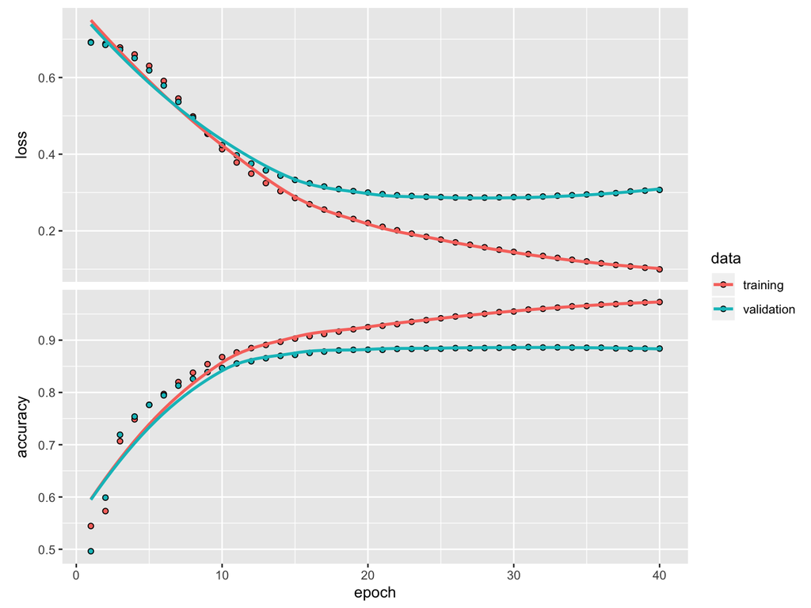

```r
plot(history)
```

The evolution of loss and metrics can also be seen during training in the RStudio Viewer pane.

Notice the training loss decreases with each epoch and the training accuracy increases with each epoch. This is expected when using gradient descent optimization — it should minimize the desired quantity on every iteration.

This isn’t the case for the validation loss and accuracy — they seem to peak after about twenty epochs. This is an example of overfitting: the model performs better on the training data than it does on data it has never seen before. After this point, the model over-optimizes and learns representations specific to the training data that do not generalize to test data.

For this particular case, we could prevent overfitting by simply stopping the training after twenty or so epochs. This was shown using callbacks in the previous lecture markdown.